# Differential expression analysis for 2024-06 release JAX_RNAseq4_ExEm_brain

Si Liu, Wei Sun

2024-11-20

Differential expression using the JAX_RNAseq4_ExEm_brain bulk RNAseq data from the June release.

There are two model systems in this dataset.

There are samples from different days.

There is only one knockout strategy: PTC.

## R libraries.

```r
library(ggplot2)
library(ggrepel)
library(ggpubr)
library(stringr)
library(MASS)
library(RColorBrewer)
library(DESeq2)

library(viridis)
library(ggpointdensity)
library(dplyr)
library(data.table)
library(ComplexHeatmap)
library(UpSetR)
library(readxl)
theme_set(theme_classic())

path = "../../MorPhiC/data/June-2024/JAX_RNAseq4_ExEm_brain/"
dat_path = paste0(path, "processed/release110-gencode44/Tables")
```

## Read in meta data

```r
meta = fread("data/June_2024/JAX_RNAseq4_ExEm_brain_meta_data.tsv",
             data.table = FALSE)
dim(meta)
```

```
## [1] 28 36
```

```r
meta[1:2,]
```

```
##   clonal.label library_preparation.label            label
## 1 MOK20001-WT1                GT24-02321 CBO-MOK20001-WT1
## 2 MOK20001-WT2                GT24-02322 CBO-MOK20001-WT2
##                               description differentiated_product_protocol_id
## 1 KOLF2.2 derived cortical brain organoid                           JAXPD003
## 2 KOLF2.2 derived cortical brain organoid                           JAXPD003
##   model_system timepoint_value timepoint_unit final_timepoint
## 1          CBO               9           days             Yes
## 2          CBO               9           days             Yes
##   treatment_condition wt_control_status ko_strategy ko_gene
## 1      Not applicable                WT          WT      WT
## 2      Not applicable                WT          WT      WT
##   library_preparation.description
## 1                              NA
## 2                              NA
##   library_preparation.library_preparation_protocol_id
## 1                                            JAXPL001
## 2                                            JAXPL001
##   library_preparation.average_fragment_size
## 1                                       406
## 2                                       406
##   library_preparation.input_amount_value library_preparation.input_amount_unit
## 1                                    300                                    ng
## 2                                    300                                    ng
##   library_preparation.concentration_value
## 1                                39.18495
## 2                                41.05090
##   library_preparation.concentration_unit library_preparation.total_yield_value
## 1                                     nM                                   189
## 2                                     nM                                   198
##   library_preparation.total_yield_unit library_preparation.cdna_pcr_cycles
## 1                                   ng                                  10
## 2                                   ng                                  10
##   library_preparation.pcr_cycles_for_indexing
## 1                               Not available
## 2                               Not available
##                                              file_id                 run_id
## 1 DMRTA1_WT_1_GT24-02321_CAATTAAC-ATATCTCG_S194_L005 20240429_24-robson-015
## 2 DMRTA1_WT_2_GT24-02322_TGGCCGGT-GCGCTCTA_S207_L005 20240429_24-robson-015
##   clonal.description clonal.parental_name clonal.clone_id clonal.type
## 1            KOLF2.2             KOLF2.2J             WT1        iPSC
## 2            KOLF2.2             KOLF2.2J             WT2        iPSC
##   clonal.zygosity clonal.cell_line_generation_protocol
## 1  Not applicable                       Not applicable
## 2  Not applicable                       Not applicable
##   clonal.treatment_condition clonal.wt_control_status
## 1             Not applicable                       WT
## 2             Not applicable                       WT
##   expression_alteration.label                                  model_organ
## 1              Not applicable Cortical brain (dorsal forebrain patterning)
## 2              Not applicable Cortical brain (dorsal forebrain patterning)
```

```r
names(meta)
```

```
##  [1] "clonal.label"
##  [2] "library_preparation.label"
##  [3] "label"
##  [4] "description"
##  [5] "differentiated_product_protocol_id"
##  [6] "model_system"
##  [7] "timepoint_value"
##  [8] "timepoint_unit"
##  [9] "final_timepoint"
## [10] "treatment_condition"
## [11] "wt_control_status"
## [12] "ko_strategy"
## [13] "ko_gene"
## [14] "library_preparation.description"
## [15] "library_preparation.library_preparation_protocol_id"
```

[output cut: 21 more lines]

```r
table(meta$clonal.label)
```

```
##
##       MOK20001-WT1       MOK20001-WT2       MOK20001-WT4      MOK20001P-B11
##                  1                  1                  1                  1
##      MOK20001P-C11      MOK20001P-F09       MOK20005-WT2      MOK20005P-A01
##                  1                  1                  1                  1
##      MOK20005P-B03      MOK20005P-C10       MOK20020-WT1       MOK20020-WT2
##                  1                  1                  1                  1
##       MOK20020-WT3      MOK20020P-A02      MOK20020P-B03      MOK20020P-C10
##                  1                  1                  1                  1
## MOK20036_41_42-WT1 MOK20036_41_42-WT2 MOK20036_41_42-WT3      MOK20036P-A01
##                  1                  1                  1                  1
##      MOK20036P-B03      MOK20036P-C03      MOK20041P-A06      MOK20041P-F07
##                  1                  1                  1                  1
##      MOK20041P-F08      MOK20042P-A09      MOK20042P-A11      MOK20042P-B10
##                  1                  1                  1                  1
```

```r
table(table(meta$clonal.label))
```

```
##
##  1
## 28
```

```r
table(table(meta$library_preparation.label))
```

```
##
##  1
## 28
```

```r
table(table(meta$label))
```

```
##
##  1
## 28
```

## Read in gene count data and filter genes

```r
cts = fread(file.path(dat_path, "genesCounts.csv"), data.table = FALSE)
dim(cts)
```

```
## [1] 38592    29
```

```r
cts[1:2, c(1:2, (ncol(cts)-1):ncol(cts))]
```

```
##              Name ZBTB7C_PTC_A09_GT23-14989_GGAGCGTC-GCACGGAC_S43_L001
## 1 ENSG00000268674                                                    0
## 2 ENSG00000271254                                                 1222
##   WT_PITX1_LMO2_ZBTB7C_3_GT23-14994_ATATCTCG-ACTAAGAT_S45_L001
## 1                                                            0
## 2                                                         1378
##   TBR1_PTC_B03-_GT23-15126_AATGCCTC-TGGATCGA_S151_L003
## 1                                                    0
## 2                                                  713
```

```r
stopifnot(setequal(names(cts)[-1], meta$file_id))

meta = meta[match(names(cts)[-1], meta$file_id),]
table(names(cts)[-1] == meta$file_id)
```

```
##
## TRUE
##   28
```

```r
cts_dat = data.matrix(cts[,-1])
rownames(cts_dat) = cts$Name

table(meta$model_organ, meta$timepoint_value)
```

```
##
##                                                 6  9 32
##   Cortical brain (dorsal forebrain patterning)  0  6  4
##   Extra-embryonic primitive syncytial cells    18  0  0
```

```r
unique_timepoints = unique(meta$timepoint_value)
unique_timepoints = sort(unique_timepoints)

xx = as.character(meta$timepoint_value)
xx = factor(xx, levels = as.character(unique_timepoints))
meta$timepoint = xx
```

### Read in gene annoation

```r
gene_anno = fread("data/gencode_v44_primary_assembly_info.tsv")
dim(gene_anno)
```

```
## [1] 62754     8
```

```r
gene_anno[1:2,]
```

```
##                geneId    chr strand     start       end ensembl_gene_id
##                <char> <char> <char>     <int>     <int>          <char>
## 1: ENSG00000000003.16   chrX      - 100627108 100639991 ENSG00000000003
## 2:  ENSG00000000005.6   chrX      + 100584936 100599885 ENSG00000000005
##    hgnc_symbol                                       description
##         <char>                                            <char>
## 1:      TSPAN6 tetraspanin 6 [Source:HGNC Symbol;Acc:HGNC:11858]
## 2:        TNMD   tenomodulin [Source:HGNC Symbol;Acc:HGNC:17757]
```

```r
table(rownames(cts_dat) %in% gene_anno$ensembl_gene_id)
```

```
##
##  TRUE
## 38592
```

```r
# all ensembl gene IDs are contained in the annotation
setdiff(rownames(cts_dat), gene_anno$ensembl_gene_id)
```

```
## character(0)
```

### Discard genes whose expression is 0 in more than 75% of samples

```r
model_s = meta$model_system
table(model_s, useNA="ifany")
```

```
## model_s
## CBO PrS
##  10  18
```

```r
get_q75 <- function(x){quantile(x, probs = 0.75)}

# there are two levels for model_system
# the result from apply(cts_dat, 1, tapply, model_s, min) is a matrix
# do transpose to the results from apply(cts_dat, 1, tapply, model_s, min)
gene_info = data.frame(Name = cts$Name,
                       t(apply(cts_dat, 1, tapply, model_s, min)),
                       t(apply(cts_dat, 1, tapply, model_s, median)),
                       t(apply(cts_dat, 1, tapply, model_s, get_q75)),
                       t(apply(cts_dat, 1, tapply, model_s, max)))

dim(gene_info)
```

```
## [1] 38592     9
```

```r
gene_info[1:2, ]
```

```
##                            Name CBO PrS CBO.1 PrS.1  CBO.2  PrS.2 CBO.3 PrS.3
## ENSG00000268674 ENSG00000268674   0   0     0     0    0.0    0.0     0     0
## ENSG00000271254 ENSG00000271254 610 790  1883  1366 2098.5 1445.5  2189  1837
```

```r
table(row.names(gene_info)==gene_info$Name)
```

```
##
##  TRUE
## 38592
```

```r
names(gene_info)[2:9] = paste0(rep(c("CBO_", "PrS_"), times=4),
                               rep(c("min", "median", "q75", "max"), each=2))
dim(gene_info)
```

```
## [1] 38592     9
```

```r
gene_info[1:2,]
```

```
##                            Name CBO_min PrS_min CBO_median PrS_median CBO_q75
## ENSG00000268674 ENSG00000268674       0       0          0          0     0.0
## ENSG00000271254 ENSG00000271254     610     790       1883       1366  2098.5
##                 PrS_q75 CBO_max PrS_max
## ENSG00000268674     0.0       0       0
## ENSG00000271254  1445.5    2189    1837
```

```r
summary(gene_info[,-1])
```

```
##     CBO_min            PrS_min           CBO_median         PrS_median
##  Min.   :     0.0   Min.   :     0.0   Min.   :     0.0   Min.   :     0.0
##  1st Qu.:     0.0   1st Qu.:     0.0   1st Qu.:     0.0   1st Qu.:     0.0
##  Median :     0.0   Median :     0.0   Median :     2.5   Median :     2.0
##  Mean   :   210.6   Mean   :   490.8   Mean   :   619.8   Mean   :   799.7
##  3rd Qu.:    81.0   3rd Qu.:   112.0   3rd Qu.:   284.5   3rd Qu.:   191.5
##  Max.   :154748.0   Max.   :226648.0   Max.   :434142.5   Max.   :490406.5
##     CBO_q75             PrS_q75            CBO_max           PrS_max
##  Min.   :      0.0   Min.   :     0.0   Min.   :      0   Min.   :      0.0
##  1st Qu.:      0.0   1st Qu.:     0.0   1st Qu.:      1   1st Qu.:      1.0
##  Median :      5.2   Median :     3.0   Median :     14   Median :      7.0
##  Mean   :    725.3   Mean   :   927.4   Mean   :   1016   Mean   :   1184.0
##  3rd Qu.:    353.3   3rd Qu.:   240.2   3rd Qu.:    493   3rd Qu.:    337.2
##  Max.   :1200765.0   Max.   :518318.0   Max.   :1783750   Max.   :1048130.0
```

```r
table(gene_info$CBO_q75 > 0, gene_info$PrS_q75 > 0)
```

```
##
##         FALSE  TRUE
##   FALSE 11115  1958
##   TRUE   3361 22158
```

```r
w2kp = which(gene_info$CBO_q75 > 0 | gene_info$PrS_q75 > 0)
cts_dat = cts_dat[w2kp,]
dim(cts_dat)
```

```
## [1] 27477    28
```

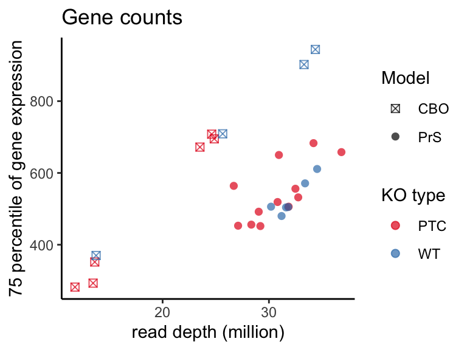

```r
gene_info = gene_info[w2kp,]

meta$read_depth = colSums(cts_dat)/1e6
meta$q75 = apply(cts_dat, 2, quantile, probs = 0.75)

# there are more than one model systems here
# need to set shape using model_system
ggplot(meta, aes(x=read_depth, y=q75, color=ko_strategy, shape = model_system)) +
    geom_point(size=2, alpha=0.7) + ggtitle("Gene counts") +
  scale_shape_manual(values = c(7, 16)) +
  xlab("read depth (million)") + ylab("75 percentile of gene expression") +
  labs(color = "KO type", shape = "Model") +
  scale_color_brewer(palette = "Set1")
```

```r
meta$run_id_short = str_replace(meta$run_id, "^[^-]*-", "")

table(meta$model_system, meta$run_id_short)
```

```
##
##       robson-015 robson-016 robson-018 robson-020
##   CBO          6          0          0          4
##   PrS          0          6         12          0
```

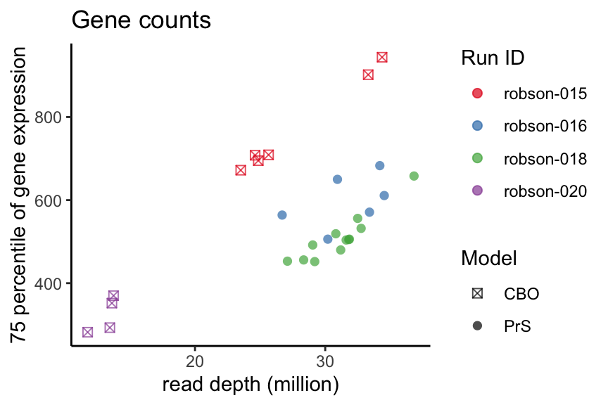

```r
ggplot(meta, aes(x=read_depth, y=q75, color=run_id_short, shape = model_system)) +
    geom_point(size=2, alpha=0.7) + ggtitle("Gene counts") +
  scale_shape_manual(values = c(7, 16)) +
  xlab("read depth (million)") + ylab("75 percentile of gene expression") +
  labs(color = "Run ID", shape = "Model") +
  scale_color_brewer(palette = "Set1")
```

## Check the effect of run id among WT

```r
sample2kp = which(meta$ko_gene == "WT")
cts_dat_m = cts_dat[,sample2kp]
meta_m    = meta[sample2kp,]
summary(meta_m$q75)
```

```
##    Min. 1st Qu.  Median    Mean 3rd Qu.    Max.
##   370.0   504.2   538.5   610.2   684.5   944.0
```

```r
dim(cts_dat_m)
```

```
## [1] 27477    10
```

```r
stopifnot(all(meta_m$file_id == colnames(cts_dat_m)))
table(meta_m$file_id == colnames(cts_dat_m), useNA="ifany")
```

```
##
## TRUE
##   10
```

```r
q75 = apply(cts_dat_m, 1, quantile, probs=0.75)
cts_dat_n = t(cts_dat_m[q75 > 0,])
cts_dat_n = log(median(meta_m$q75)*cts_dat_n/meta_m$q75 + 1)
dim(cts_dat_n)
```

```
## [1]    10 25085
```

```r
sample_pca = prcomp(cts_dat_n, center = TRUE, scale. = TRUE)
names(sample_pca)
```

```
## [1] "sdev"     "rotation" "center"   "scale"    "x"
```

```r
pc_scores = sample_pca$x
eigen_vals = sample_pca$sdev^2
eigen_vals[1:5]/sum(eigen_vals)
```

```
## [1] 0.53360152 0.21414118 0.11253834 0.02813644 0.02611805
```

```r
pvs = round(eigen_vals[1:5]/sum(eigen_vals)*100,1)
pvs
```

```
## [1] 53.4 21.4 11.3  2.8  2.6
```

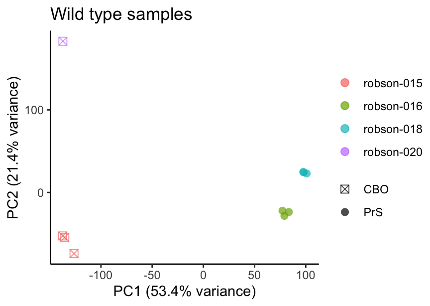

```r
PC_df = data.frame(pc_scores)
PC_df = cbind(PC_df, meta_m)

# there are two levels for model_system here
# need to use model_system for the shape
gPC = ggplot(PC_df, aes(x = PC1, y = PC2, shape=model_system,
                        color=run_id_short)) +
  geom_point(size=2.5, alpha=0.7) +
  #scale_color_brewer(palette = "Dark2") +
  scale_shape_manual(values = c(7, 16)) +
  labs(color="Run id", shape ="Model") +
  xlab(sprintf("PC1 (%.1f%% variance)", pvs[1])) +
  ylab(sprintf("PC2 (%.1f%% variance)", pvs[2])) +
  ggtitle("Wild type samples") +
  guides(
    color = guide_legend(title = NULL, order = 1),
    shape = guide_legend(title = NULL, order = 2)
  ) +
  theme(
    legend.margin = margin(0, 0, 0, 0),
    legend.box.just = "left",
    legend.direction = "vertical"
  )

print(gPC)
```

```r
table(PC_df$run_id, PC_df$timepoint)
```

```
##
##                          6 9 32
##   20231214_23-robson-016 3 0  0
##   20231226_23-robson-018 3 0  0
##   20240131_23-robson-020 0 0  1
##   20240429_24-robson-015 0 3  0
```

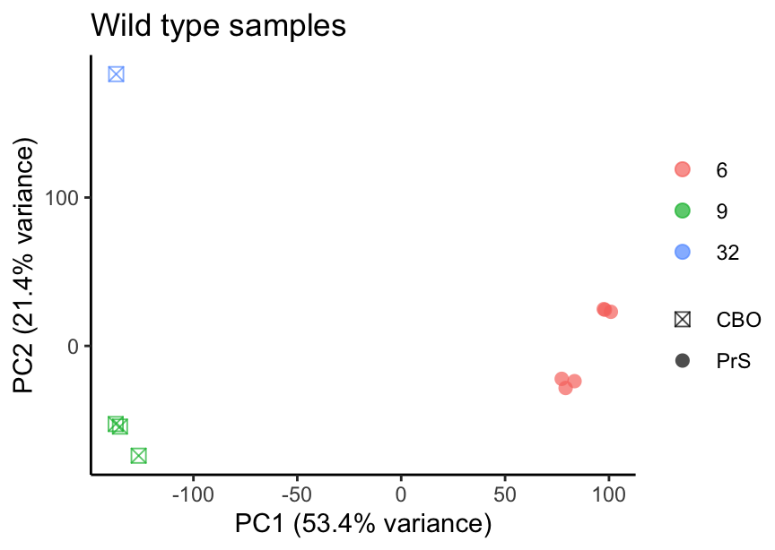

```r
gPC_time = ggplot(PC_df, aes(x = PC1, y = PC2, shape=model_system,
                            color=timepoint)) +
  geom_point(size=2.5, alpha=0.7) +
  #scale_color_brewer(palette = "Dark2") +
  scale_shape_manual(values = c(7, 16)) +
  labs(color="Day", shape ="Model") +
  xlab(sprintf("PC1 (%.1f%% variance)", pvs[1])) +
  ylab(sprintf("PC2 (%.1f%% variance)", pvs[2])) +
  ggtitle("Wild type samples") +
  guides(
    color = guide_legend(title = NULL, order = 1),
    shape = guide_legend(title = NULL, order = 2)
  ) +
  theme(
    legend.margin = margin(0, 0, 0, 0),
    legend.box.just = "left",
    legend.direction = "vertical"
  )

print(gPC_time)
```

## Analyze samples of different model systems or batches

Explore the PC plots first, to decide running the models on what level of DE group.

Then run the DE analysis.

```r
table(meta$run_id, meta$model_system)
```

```
##
##                          CBO PrS
##   20231214_23-robson-016   0   6
##   20231226_23-robson-018   0  12
##   20240131_23-robson-020   4   0
##   20240429_24-robson-015   6   0
```

```r
table(meta$run_id, meta$ko_gene)
```

```
##
##                          DMRTA1 LMO2 OVOL1 PITX1 TBR1 WT ZBTB7C
##   20231214_23-robson-016      0    0     3     0    0  3      0
##   20231226_23-robson-018      0    3     0     3    0  3      3
##   20240131_23-robson-020      0    0     0     0    3  1      0
##   20240429_24-robson-015      3    0     0     0    0  3      0
```

```r
table(meta$ko_strategy, meta$ko_gene)
```

```
##
##       DMRTA1 LMO2 OVOL1 PITX1 TBR1 WT ZBTB7C
##   PTC      3    3     3     3    3  0      3
##   WT       0    0     0     0    0 10      0
```

```
## [1] ""
## [1] "=========================================="
## [1] "CBO"
## [1] "=========================================="
## [1] ""
##
##  1
## 10
##
##       PTC WT
##   PTC   6  0
##   WT    0  4
```

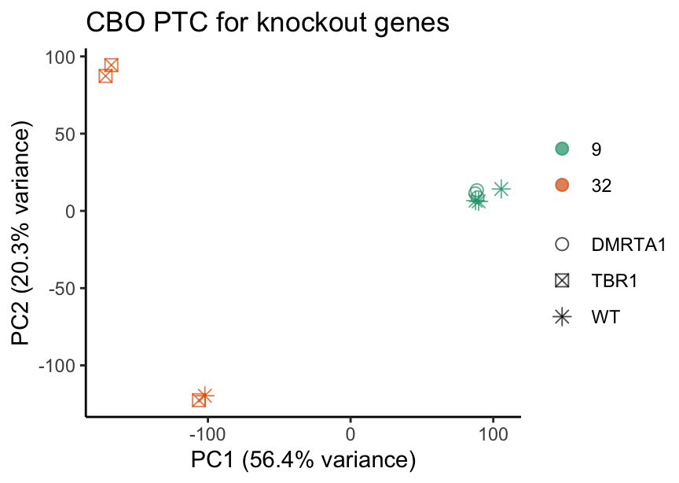

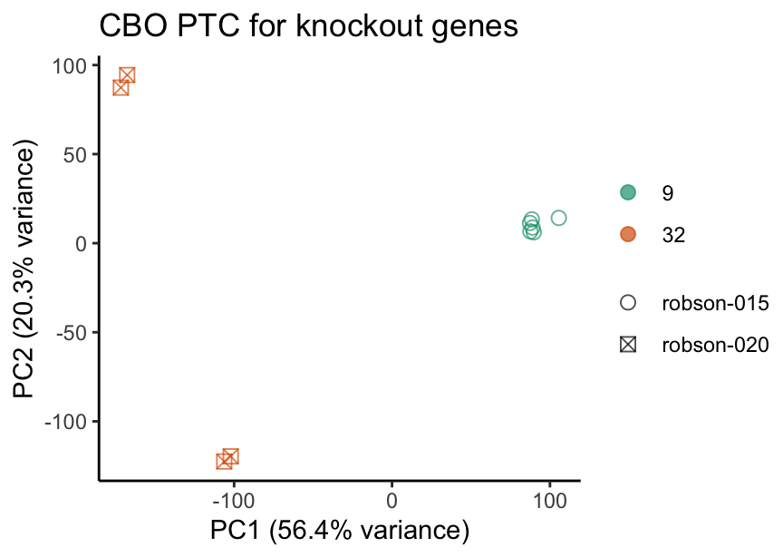

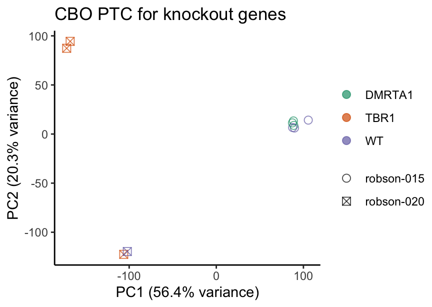

```
## [1] ""
## [1] "=========================================="
## [1] "PrS"
## [1] "=========================================="
## [1] ""
##
##  1
## 18
##
##       PTC WT
##   PTC  12  0
##   WT    0  6
```

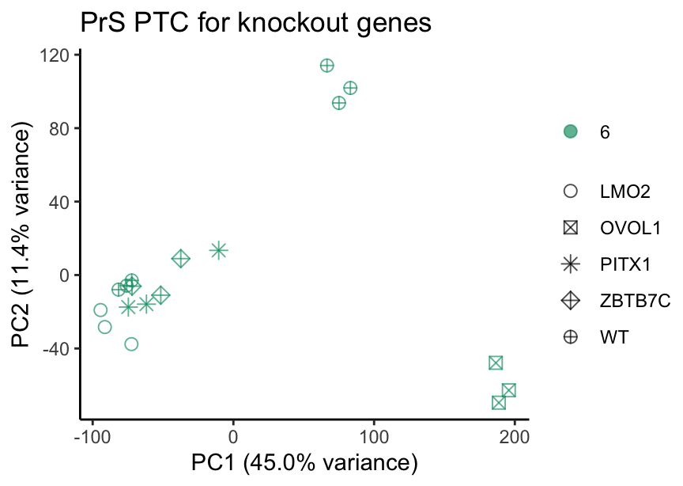

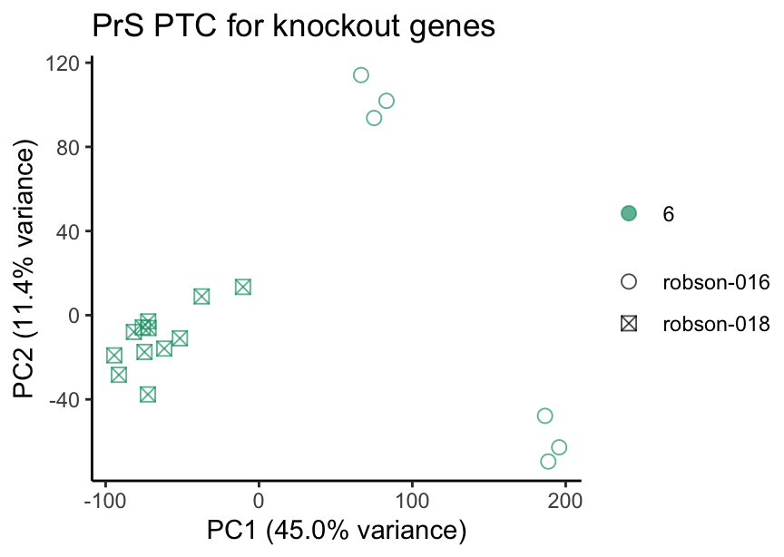

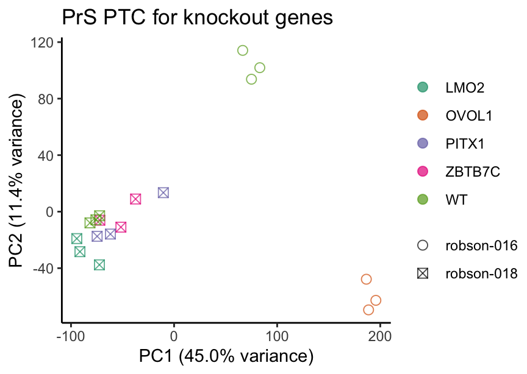

```r
unique_model_ss = unique(meta$model_system)
unique_model_ss = sort(unique_model_ss)

for(model1 in unique_model_ss){
  print("")
  print("==========================================")
  print(model1)
  print("==========================================")
  print("")

  sample2kp = which(meta$model_system == model1)
  cts_dat_m = cts_dat[,sample2kp]
  meta_m    = meta[sample2kp,]

  # verify the consistency between ko_strategy from metadata column and
  # that from filenames
  extracted_ko_strings = str_extract_all(meta_m$file_id, "PTC|WT")
  print(table(sapply(extracted_ko_strings, length)))
  print(table(meta_m$ko_strategy, unlist(extracted_ko_strings)))

  stopifnot(all(meta_m$file_id == colnames(cts_dat_m)))


  q75 = apply(cts_dat_m, 1, quantile, probs=0.75)

  cts_dat_n = t(cts_dat_m[q75 > 0,])
  cts_dat_n = log(median(meta_m$q75)*cts_dat_n/meta_m$q75 + 1)
  dim(cts_dat_n)

  sample_pca = prcomp(cts_dat_n, center = TRUE, scale. = TRUE)
  names(sample_pca)
  pc_scores = sample_pca$x
  eigen_vals = sample_pca$sdev^2
  eigen_vals[1:5]/sum(eigen_vals)
  pvs = round(eigen_vals[1:5]/sum(eigen_vals)*100,1)
  pvs

  PC_df = data.frame(pc_scores)
  PC_df = cbind(PC_df, meta_m)

  colnames(PC_df)[which(colnames(PC_df)=="timepoint")] = "day"

  only_ko_strategy = setdiff(unique(PC_df$ko_strategy), "WT")

  unique_ko_genes = sort(unique(PC_df$ko_gene))
  unique_ko_genes = c(unique_ko_genes[unique_ko_genes!="WT"], "WT")
  PC_df$ko_gene = factor(PC_df$ko_gene, unique_ko_genes)

  shapes = c(1, 7, 8, 9, 10, 11, 15, 16, 17)


  gPC = ggplot(PC_df, aes(x = PC1, y = PC2, shape=ko_gene, color=day)) +
  geom_point(size=2.5, alpha=0.7) + scale_color_brewer(palette = "Dark2") +
    scale_shape_manual(values = shapes[1:length(unique(PC_df$ko_gene))]) +
  xlab(sprintf("PC1 (%.1f%% variance)", pvs[1])) +
  ylab(sprintf("PC2 (%.1f%% variance)", pvs[2])) +
  ggtitle(paste0(model1, " ", only_ko_strategy, " for knockout genes")) +
  guides(
    color = guide_legend(title = NULL, order = 1),
    shape = guide_legend(title = NULL, order = 2)
  ) +
  theme_classic() +
  theme(
    legend.margin = margin(0, 0, 0, 0),
    legend.box.just = "left",
    legend.direction = "vertical"
  )

  print(gPC)

  gPC = ggplot(PC_df, aes(x = PC1, y = PC2, shape=run_id_short, color=day)) +
  geom_point(size=2.5, alpha=0.7) +
  scale_color_brewer(palette = "Dark2") +
  scale_shape_manual(values = shapes[1:length(unique(PC_df$run_id_short))]) +
  xlab(sprintf("PC1 (%.1f%% variance)", pvs[1])) +
  ylab(sprintf("PC2 (%.1f%% variance)", pvs[2])) +
  ggtitle(paste0(model1, " ", only_ko_strategy, " for knockout genes")) +
  guides(
    color = guide_legend(title = NULL, order = 1),
    shape = guide_legend(title = NULL, order = 2)
  ) +
  theme_classic() +
  theme(
    legend.margin = margin(0, 0, 0, 0),
    legend.box.just = "left",
    legend.direction = "vertical"
  )

  print(gPC)



  gPC = ggplot(PC_df, aes(x = PC1, y = PC2, shape=run_id_short, color=ko_gene)) +
  geom_point(size=2.5, alpha=0.7) +
  scale_color_brewer(palette = "Dark2") +
  scale_shape_manual(values = shapes[1:length(unique(PC_df$run_id_short))]) +
  xlab(sprintf("PC1 (%.1f%% variance)", pvs[1])) +
  ylab(sprintf("PC2 (%.1f%% variance)", pvs[2])) +
  ggtitle(paste0(model1, " ", only_ko_strategy, " for knockout genes")) +
  guides(
    color = guide_legend(title = NULL, order = 1),
    shape = guide_legend(title = NULL, order = 2)
  ) +
  theme(
    legend.margin = margin(0, 0, 0, 0),
    legend.box.just = "left",
    legend.direction = "vertical"
  )

  print(gPC)

}
```

Use model system + day or model system + day + run_id to construct DE group.

Exclude CBO day 32, because it only has one WT sample.

Run DESeq2 for different DE groups separately

```
  CBO, day 9 only
  PrS, day 6, for two run_ids separately
```

For the output files, create two versions, one with direct information, one with padj set to NA for the genes when the number of 0 per test is >=4.

In more details, for both versions of the outputs, make it one file per knockout gene per DE group (DE group can be model system, model system + condition, model system + run_id, model system + day, etc.).

The first version of the output files contains

```
gene id, gene symbol
```

and for each knockout strategy:

```
baseMean, log2FoldChange, lfcSE, stat, pvalue, padj
```

The second version of the output files contains

```
gene id, gene symbol, chr, strand, position
```

and for each knockout strategy:

```
log2FoldChange, pvalue, padj (set to be NA if the number of 0 per test >= 4),
```

In addition, save out a separate file of the sample size for each comparison. This needs to be by DE group.

### Prepare output directories for DE results

```r
df_size = NULL

release_name = "2024_06_JAX_RNAseq4_ExEm_brain"

output_dir = file.path("results", release_name)
raw_output_dir = file.path(output_dir, "raw")
processed_output_dir = file.path(output_dir, "processed")

if (!file.exists(raw_output_dir)){
  dir.create(raw_output_dir, recursive = TRUE)
}

if (!file.exists(processed_output_dir)){
  dir.create(processed_output_dir, recursive = TRUE)
}
```

### DE analysis for all genes

```
## [1] ""
## [1] "=========================================="
## [1] "CBO"
## [1] "=========================================="
## [1] ""
##
##                          DMRTA1 TBR1 WT
##   20240131_23-robson-020      0    3  1
##   20240429_24-robson-015      3    0  3
##
##          6 9 32
##   DMRTA1 0 3  0
##   TBR1   0 0  3
##   WT     0 3  1
##
##                     6 9 32
##   DMRTA1_robson-015 0 3  0
##   TBR1_robson-020   0 0  3
##   WT_robson-015     0 3  0
##   WT_robson-020     0 0  1
## [1] "---------------------------"
## [1] "Model system: CBO"
## [1] "On day 9: "
##
##          robson-015
##   DMRTA1          3
##   WT              3
## [1] "---------------------------"
## [1] "Model system: CBO"
## [1] "On day 32: "
##
##        robson-020
##   TBR1          3
##   WT            1
## [1] ""
## [1] "-----------------------------------"
## [1] "Model system: CBO"
## [1] "DE group CBO_day_9 DESeq2 results:"
## [1] "-----------------------------------"
## [1] "After filtering by gene expression q75, the number of genes reduces from 27477 to 23605"
## [1] "After filtering by nonzero expression in at least 4 samples, the number of genes reduces from 23605 to 21336"
## Time difference of 18.68078 secs
```

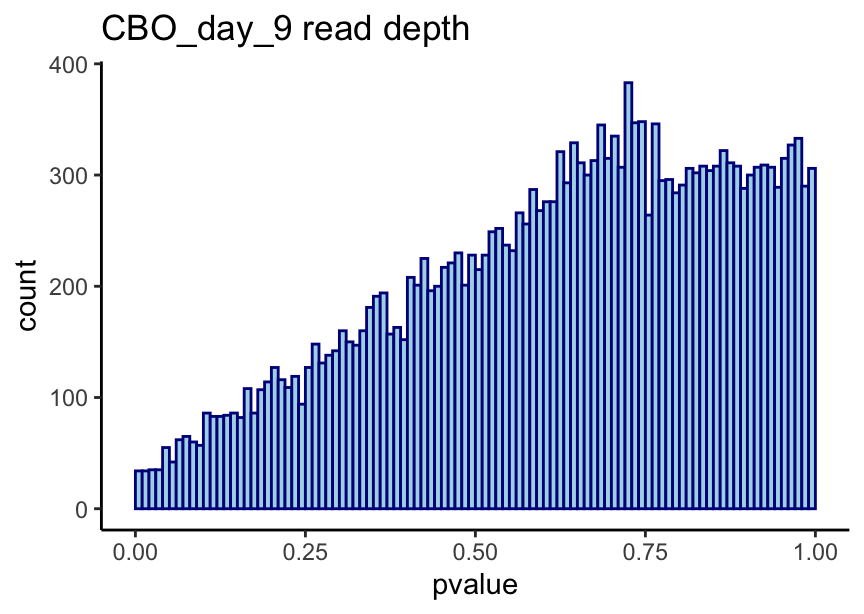

```
## [1] "prop of non-null for rd: 0.00e+00"
## [1] "rerun DESeq2 without read depth"
## [1] "CBO_day_9 under KO gene DMRTA1:"
## [1] " number of DE genes: 386"
```

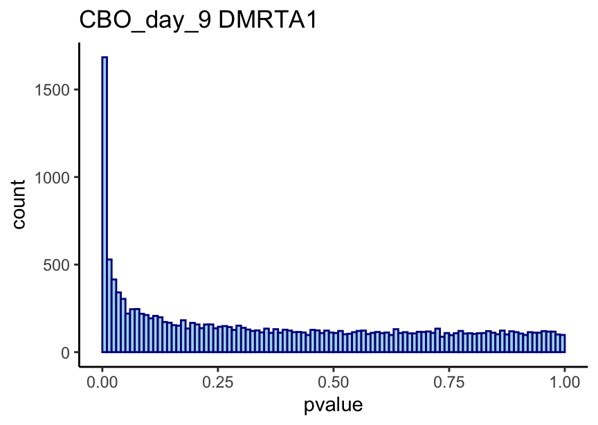

```
## [1] "hgnc_symbol empty string and NA tables:"
##
## FALSE  <NA>
## 17471  3865
##
## FALSE  TRUE
## 17471  3865
## [1] ""
## [1] "-----------------------------------"
## [1] "Model system: CBO"
## [1] "DE group CBO_day_32 has only 1 wild type samples"
## [1] "do not run DESeq2 for it"
## [1] "-----------------------------------"
## [1] ""
## [1] "=========================================="
## [1] "PrS"
## [1] "=========================================="
## [1] ""
##
##                          LMO2 OVOL1 PITX1 WT ZBTB7C
##   20231214_23-robson-016    0     3     0  3      0
##   20231226_23-robson-018    3     0     3  3      3
##
##          6 9 32
##   LMO2   3 0  0
##   OVOL1  3 0  0
##   PITX1  3 0  0
##   WT     6 0  0
##   ZBTB7C 3 0  0
##
##                     6 9 32
##   LMO2_robson-018   3 0  0
##   OVOL1_robson-016  3 0  0
##   PITX1_robson-018  3 0  0
##   WT_robson-016     3 0  0
##   WT_robson-018     3 0  0
##   ZBTB7C_robson-018 3 0  0
## [1] "---------------------------"
## [1] "Model system: PrS"
## [1] "On day 6: "
##
##          robson-016 robson-018
##   LMO2            0          3
##   OVOL1           3          0
##   PITX1           0          3
##   WT              3          3
##   ZBTB7C          0          3
## [1] ""
## [1] "-----------------------------------"
## [1] "Model system: PrS"
## [1] "DE group PrS_day_6_20231214_23-robson-016 DESeq2 results:"
## [1] "-----------------------------------"
## [1] "After filtering by gene expression q75, the number of genes reduces from 27477 to 22660"
## [1] "After filtering by nonzero expression in at least 4 samples, the number of genes reduces from 22660 to 20005"
## Time difference of 22.28583 secs
```

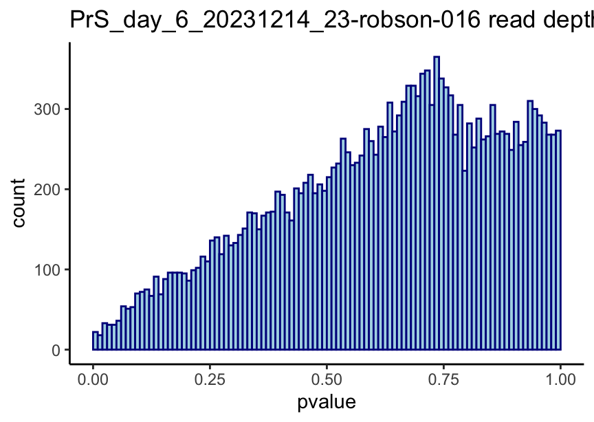

```
## [1] "prop of non-null for rd: 0.00e+00"
## [1] "rerun DESeq2 without read depth"
## [1] "PrS_day_6_20231214_23-robson-016 under KO gene OVOL1:"
## [1] " number of DE genes: 4476"
```

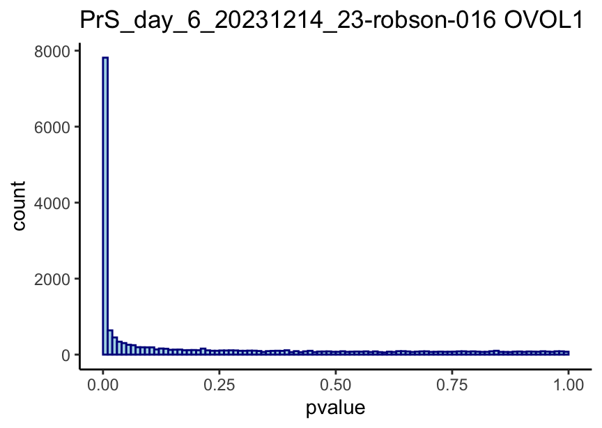

```
## [1] "hgnc_symbol empty string and NA tables:"
##
## FALSE  <NA>
## 16901  3104
##
## FALSE  TRUE
## 16901  3104
## [1] ""
## [1] "-----------------------------------"
## [1] "Model system: PrS"
## [1] "DE group PrS_day_6_20231226_23-robson-018 DESeq2 results:"
## [1] "-----------------------------------"
## [1] "After filtering by gene expression q75, the number of genes reduces from 27477 to 24428"
## [1] "After filtering by nonzero expression in at least 4 samples, the number of genes reduces from 24428 to 23762"
## Time difference of 42.72095 secs
```

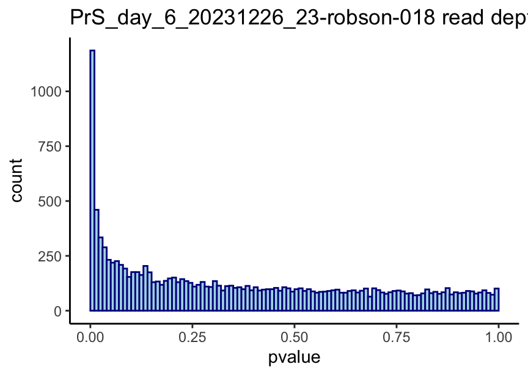

```
## [1] "prop of non-null for rd: 3.20e-01"
## [1] "PrS_day_6_20231226_23-robson-018 under KO gene ZBTB7C:"
## [1] " number of DE genes: 106"
```

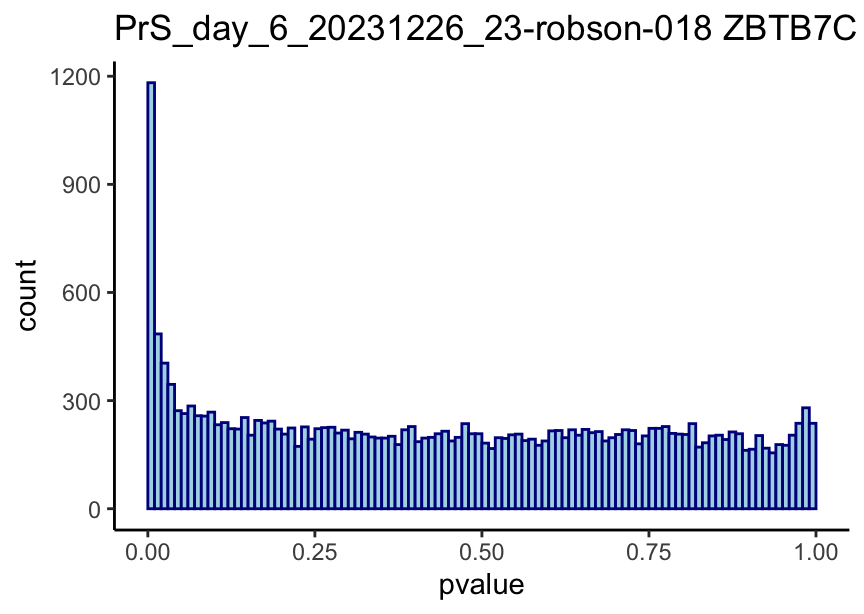

```
## [1] "hgnc_symbol empty string and NA tables:"
##
## FALSE  <NA>
## 19023  4739
##
## FALSE  TRUE
## 19023  4739
## [1] "PrS_day_6_20231226_23-robson-018 under KO gene PITX1:"
## [1] " number of DE genes: 26"
```

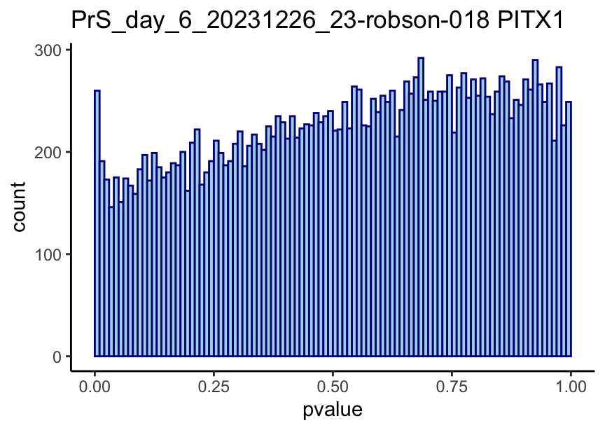

```
## [1] "hgnc_symbol empty string and NA tables:"
##
## FALSE  <NA>
## 19023  4739
##
## FALSE  TRUE
## 19023  4739
## [1] "PrS_day_6_20231226_23-robson-018 under KO gene LMO2:"
## [1] " number of DE genes: 63"
```

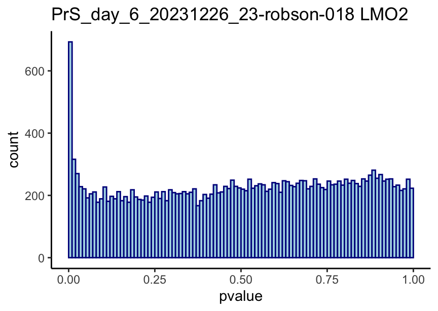

```
## [1] "hgnc_symbol empty string and NA tables:"
##
## FALSE  <NA>
## 19023  4739
##
## FALSE  TRUE
## 19023  4739
```

```r
for(model1 in unique_model_ss){

  print("")
  print("==========================================")
  print(model1)
  print("==========================================")
  print("")

  sample2kp = which(meta$model_system == model1)
  cts_dat_m = cts_dat[,sample2kp]
  meta_m    = meta[sample2kp,]

  table(meta_m$ko_strategy)
  stopifnot(all(meta_m$file_id == colnames(cts_dat_m)))

  ## Generate sample information matrix
  cols2kp = c("model_system", "ko_strategy", "ko_gene", "run_id", "run_id_short",
              "timepoint", "q75")
  sample_info = meta_m[,cols2kp]
  colnames(sample_info)[which(colnames(sample_info)=="timepoint")] = "day"

  dim(sample_info)
  sample_info[1:2,]

  sample_info$ko_gene_run_id = paste(sample_info$ko_gene,
                                      sample_info$run_id_short, sep="_")

  print(table(sample_info$run_id, sample_info$ko_gene))
  print(table(sample_info$ko_gene, sample_info$day))
  print(table(sample_info$ko_gene_run_id, sample_info$day))

  # print the table of ko_gene and run_id by day
  unique_timepoints_model_s = unique(sample_info$day)
  unique_timepoints_model_s = as.character(sort(unique_timepoints_model_s))

  for (cur_day in as.character(unique_timepoints_model_s)){
    sample_info_by_day = sample_info[which(sample_info$day==as.character(cur_day)), ]
    print("---------------------------")
    print(paste0("Model system: ", model1))
    print(paste0("On day ", as.character(cur_day), ": "))
    print(table(sample_info_by_day$ko_gene, sample_info_by_day$run_id_short))
  }

  # run DESeq2 for different day groups separately
  # For model system CBO:
  # day 9
  # day 32 (cannot do it, since there is only one WT sample)
  #
  # For model system PrS:
  # day 6
  # but need to divide the two batches

  sample_info$model_day = paste0(sample_info$model_system,
                              "_day_",
                              as.character(sample_info$day))

  sample_info$de_grp = sample_info$model_day

  if(model1 == "PrS"){
    sample_info$de_grp = paste0(sample_info$de_grp, "_",
                                sample_info$run_id)
  }

  unique_de_grps = unique(sample_info$de_grp)
  sorted_de_grps = sort(unique_de_grps)

  if(model1 == "CBO"){
      sorted_de_grps = rev(sorted_de_grps)
  }

  for (d_group in sorted_de_grps){

    dg_index = which(sample_info$de_grp==d_group)
    cts_dat_m_dg = cts_dat_m[, dg_index]
    sample_info_dg = sample_info[dg_index, ]

    stopifnot(all(sample_info_dg$de_grp==d_group))

    print("")
    print("-----------------------------------")
    print(paste0("Model system: ", model1))
    if (sum(sample_info_dg$ko_gene=="WT") < 2){
      print(sprintf("DE group %s has only %d wild type samples",
                    d_group, sum(sample_info_dg$ko_gene=="WT")))
      print(sprintf("do not run DESeq2 for it"))
      print("-----------------------------------")
      next
    }else{
      print(sprintf("DE group %s DESeq2 results:", d_group))
      print("-----------------------------------")
    }


    # do two steps of filtering
    # first, filter based on q75 of each gene
    # second, filter based on whether each gene is expressed in at least 4 cells

    dg_q75 = apply(cts_dat_m_dg, 1, quantile, probs=0.75)
    cts_dat_m_dg = cts_dat_m_dg[dg_q75 > 0,]

    print(sprintf("After filtering by gene expression q75, the number of genes reduces from %d to %d",
                  length(dg_q75), nrow(cts_dat_m_dg)))

    n_pos = rowSums(cts_dat_m_dg>0)
    cts_dat_m_dg = cts_dat_m_dg[n_pos >= 4,]

    if (length(n_pos)==nrow(cts_dat_m_dg)){
      print("After filtering by nonzero expression in at least 4 samples, the number of genes does not change.")
    }else{
      print(sprintf("After filtering by nonzero expression in at least 4 samples, the number of genes reduces from %d to %d",
                    length(n_pos), nrow(cts_dat_m_dg)))
    }

    # update the q75 based on only genes that will be used in the DE analysis
    sample_info_dg$q75 = apply(cts_dat_m_dg, 2, quantile, probs = 0.75)
    sample_info_dg$log_q75 = log(sample_info_dg$q75)

    if (length(unique(sample_info_dg$run_id))==1){
      dds = DESeqDataSetFromMatrix(cts_dat_m_dg, colData=sample_info_dg,
                                    ~ ko_gene + log_q75)
    }else{
      dds = DESeqDataSetFromMatrix(cts_dat_m_dg, colData=sample_info_dg,
                                    ~ ko_gene + run_id + log_q75)
    }

    start.time <- Sys.time()
    dds = DESeq(dds)
    end.time <- Sys.time()

    time.taken <- end.time - start.time
    print(time.taken)

    ## association with read-depth
    res_rd = results(dds, name = "log_q75")
    res_rd = as.data.frame(res_rd)
    dim(res_rd)
    res_rd[1:2,]

    table(is.na(res_rd$padj))

    g0 = ggplot(res_rd %>% subset(!is.na(padj)), aes(x=pvalue)) +
      geom_histogram(color="darkblue", fill="lightblue",
                     breaks = seq(0,1,by=0.01)) +
      ggtitle(paste0(d_group, " read depth"))
    print(g0)

    ## Rerun the analysis without read-depth if it is not significant for
    ## most genes, and the number of samples is small
    ## i.e., proportion of non-null in the distribution is smaller than 0.01
    ## (this needs to be restricted to the genes with not NA adjusted pvalue)
    ## or if smaller than 0.1 and the number of samples is not greater than 6

    pi_1_rd = max(0, mean(res_rd$pvalue[!is.na(res_rd$padj)] < 0.05) - 0.05)
    pi_1_rd = max(pi_1_rd, 0, 1 - 2*mean(res_rd$pvalue[!is.na(res_rd$padj)] > 0.5))

    print(sprintf("prop of non-null for rd: %.2e", pi_1_rd))

    if(pi_1_rd < 0.01 || (ncol(cts_dat_m_dg) <= 6 && pi_1_rd < 0.1 )){

      print("rerun DESeq2 without read depth")

      include_rd = 0

      if (length(unique(sample_info_dg$run_id))==1){
        dds = DESeqDataSetFromMatrix(cts_dat_m_dg, colData=sample_info_dg,
                                      ~ ko_gene)
      }else{
        dds = DESeqDataSetFromMatrix(cts_dat_m_dg, colData=sample_info_dg,
                                      ~ ko_gene + run_id)
      }

      dds = DESeq(dds)

    }else{
      include_rd = 1
    }

    ## association with run_id

    if (length(unique(sample_info_dg$run_id))>1){
      if(include_rd)
        dds_lrt = DESeq(dds, test="LRT", reduced = ~ ko_gene + log_q75)
      else
        dds_lrt = DESeq(dds, test="LRT", reduced = ~ ko_gene)

      res_lrt = results(dds_lrt)

      res_run_id = as.data.frame(res_lrt)
      dim(res_run_id)
      res_run_id[1:2,]

      table(is.na(res_run_id$padj))

      g0 = ggplot(res_run_id %>% subset(!is.na(padj)), aes(x=pvalue)) +
        geom_histogram(color="darkblue", fill="lightblue",
                       breaks = seq(0,1,by=0.01)) +
        ggtitle(paste0(d_group, " Run ID"))
      print(g0)

    }

    ## DE analysis for each KO gene
    table(sample_info_dg$ko_gene)

    genos = setdiff(unique(sample_info_dg$ko_gene), "WT")
    genos

    for(geno in genos){

      res_g1 = results(dds, contrast = c("ko_gene", geno, "WT"))
      res_g1 = signif(data.frame(res_g1), 3)

      # add a column to record the number of zeros per test
      test_index = which(sample_info_dg$ko_gene%in%c(geno, "WT"))

      cts_dat_m_dg_test = cts_dat_m_dg[, test_index]
      n_zero = rowSums(cts_dat_m_dg_test==0)
      res_g1$n_zeros = n_zero

      # record the number of samples involved in the comparison
      test_ko_gene_vec = sample_info_dg$ko_gene[test_index]

      df_size = rbind(df_size,
                      c(d_group,
                        paste0(geno, "_PTC"),
                        sum(test_ko_gene_vec!="WT"),
                        sum(test_ko_gene_vec=="WT")))

      # prepare a processed version of output
      res_g1_reduced = res_g1[, c("log2FoldChange", "pvalue", "padj", "n_zeros")]
      res_g1_reduced$padj[which(res_g1_reduced$n_zeros>=4)] = NA

      if ((sum(test_ko_gene_vec!="WT")==1)|(sum(test_ko_gene_vec=="WT")==1)){
        res_g1_reduced$padj = NA
      }

      res_g1_reduced = res_g1_reduced[, c("log2FoldChange", "pvalue", "padj")]

      n_DE = sum(res_g1_reduced$padj < 0.05 & abs(res_g1_reduced$log2FoldChange) > log2(1.5),
                 na.rm = TRUE)
      print(paste0(d_group, " under KO gene ", geno, ":"))
      print(sprintf(" number of DE genes: %d", n_DE))

      g1 = ggplot(res_g1_reduced %>% subset(!is.na(padj)), aes(x=pvalue)) +
        geom_histogram(color="darkblue", fill="lightblue",
                       breaks = seq(0,1,by=0.01)) +
        ggtitle(paste0(d_group, " ", geno))
      print(g1)

      tag1 = sprintf("%s_PTC_", geno)
      colnames(res_g1) = paste0(tag1, colnames(res_g1))
      colnames(res_g1_reduced) = paste0(tag1, colnames(res_g1_reduced))


      res_df = data.frame(gene_ID=rownames(res_g1),
                          res_g1)
      dim(res_df)
      res_df[1:2,]


      res_reduced_gene_anno = gene_anno[match(rownames(res_g1_reduced),
                                              gene_anno$ensembl_gene_id), ]
      stopifnot(all(rownames(res_g1_reduced)==res_reduced_gene_anno$ensembl_gene_id))

      # set gene hgnc_symbol that equal "" to NA
      hgnc_symbol_vec = res_reduced_gene_anno$hgnc_symbol
      hgnc_symbol_vec[which(hgnc_symbol_vec=="")] = NA

      res_reduced_df = data.frame(gene_ID=rownames(res_g1_reduced),
                                  hgnc_symbol=hgnc_symbol_vec,
                                  chr=res_reduced_gene_anno$chr,
                                  strand=res_reduced_gene_anno$strand,
                                  start=res_reduced_gene_anno$start,
                                  end=res_reduced_gene_anno$end,
                                  res_g1_reduced)

      print("hgnc_symbol empty string and NA tables:")
      print(table(res_reduced_df$hgnc_symbol=="", useNA="ifany"))
      print(table(is.na(res_reduced_df$hgnc_symbol)))

      dim(res_reduced_df)
      res_reduced_df[1:2,]

      setting_name = unique(sample_info_dg$model_day)

      fwrite(res_df,
             sprintf("%s/%s_%s_%s_DEseq2_raw.tsv",
                     raw_output_dir, release_name, setting_name, geno),
             sep="\t")
      fwrite(res_reduced_df,
             sprintf("%s/%s_%s_%s_DEseq2.tsv",
                     processed_output_dir, release_name, setting_name, geno),
             sep="\t")

    }

  }

}
```

Save the size dataframe out

```r
colnames(df_size) = c("DE_group", "knockout_gene_strategy", "n_ko", "n_WT")
df_size = as.data.frame(df_size)

multi_rows = which(table(df_size$knockout_gene_strategy)>1)
multi_rows
```

```
## named integer(0)
```

```r
df_size[which(df_size$knockout_gene_strategy%in%names(multi_rows)),]
```

```
## [1] DE_group               knockout_gene_strategy n_ko
## [4] n_WT
## <0 rows> (or 0-length row.names)
```

```r
fwrite(df_size,
       sprintf("%s/%s_DE_n_samples.tsv", output_dir, release_name),
       sep="\t")
```

```r
gc()
```

```
##            used  (Mb) gc trigger  (Mb) limit (Mb) max used  (Mb)
## Ncells  7895298 421.7   12621538 674.1         NA 12621538 674.1
## Vcells 20668346 157.7   36859779 281.3      65536 36859779 281.3
```